# compile-regional-data

#### Sockeye

Reconstructions of sockeye spawners and recruitment are compelted by DFO (Nicholas Brown, pers. comm.) for three Conservation Units on West Vancouver Island: Sproat, Great Central, and Hucuktlis (formerly Henderson). We used the sum of spawners and total return for these three Conservation Units as the index of sockeye spawner and total abundance for WVI. We acknowledge that this index does not account for lake-type sockeye in other watersheds (e.g., Muchalat, Kennedy, Clayoquot) or river-type sockeye in West Vancouver Island and Northwest Vancouver Island CUs, which tend to be in much lower abundance.

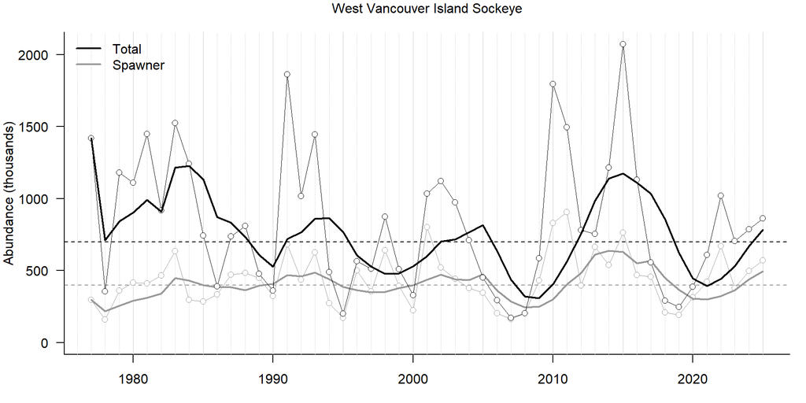

**Above:** Spawner abundance (grey) and total abundance (black) of West Vancouver Island sockeye salmon. For both, the raw data is shown by points and the smoothed metric by solid lines. Dashed horizonal lines represent the long-term average for each.

```r
# Sum of CU abundance from Sproat, Great Central, and Henderson
## Load data ---
wvi_se_raw <- readxl::read_xlsx(here("data/Barkley_Sockeye_stock-recruit_infilled.xlsx"), sheet = "S-R data")

wvi_se_summed <- wvi_se_raw %>%
    dplyr::select(year, stock, S, N) %>% # S = escapement, N = annual terminal run size
    filter(year >= 1977) %>% # Remove 1972 to 2076 for HUC because not available for other stocks
    group_by(year) %>%
    summarise(totalS = sum(S),
                        totalN = sum(N))

# plot(wvi_se_summed$year, wvi_se_summed$totalN, "o", ylim = c(0, 2e6), main = "WVI Sockeye", xlab = "", ylab = "")
# points(wvi_se_summed$year, wvi_se_summed$totalS, "o",  col = 2)
# points(yrs, sp[2, "Sockeye", ], "o", col = 4)
# legend("topleft", col = c(1,2,4), c("3 CU - Total run", "3 CU - Escape.", "NuSEDS expanded"), pch = 1, lty = 1)

# Reformat data for SPS
wvise_sps <- data.frame(
    region = rep("West Vancouver Island", dim(wvi_se_summed)[1]),
    species = rep("Sockeye", dim(wvi_se_summed)[1]),
    year = wvi_se_summed$year,
    spawners = wvi_se_summed$totalS,
    smoothedSpawners = NA,
    runsize = wvi_se_summed$totalN,
    smoothedRunsize = NA,
    source_id = rep("Brown_20260420", dim(wvi_se_summed)[1])
)

# Smoothing
wvise_sps$smoothedSpawners <- genSmooth(
    abund = wvise_sps$spawners,
    years = wvise_sps$year,
    genLength = genLength$gen_length[genLength$region == "West Vancouver Island" & genLength$species == "Sockeye"]
)

wvise_sps$smoothedRunsize <- genSmooth(
    abund = wvise_sps$runsize,
    years = wvise_sps$year,
    genLength = genLength$gen_length[genLength$region == "West Vancouver Island" & genLength$species == "Sockeye"]
)

# Add to master sps dataframe
sps_data <- rbind(sps_data, wvise_sps)

# Generate standard figure
plot_abund(wvise_sps)
```